# Predicting student performances with attributes

```r
## school, higher edu, failures, school support are significant variables of Portuguese language course
```

For Portuguese students, the number of past class failures would also be the significant variable affecting the model alongside having the desire to pursue higher education, followed by having school support.

```r
# Relationship of failures with G3 for Math and G3 in Portuguese language
m1failure <- lm(G3 ~failures, data = Mtrain)
summary(m1failure)
```

```
##
## Call:
## lm(formula = G3 ~ failures, data = Mtrain)
##
## Residuals:
##      Min       1Q   Median       3Q      Max
## -11.4915  -2.1468   0.5085   2.8532   8.8532
##
## Coefficients:
##             Estimate Std. Error t value Pr(>|t|)
## (Intercept)  11.4915     0.2864   40.13  < 2e-16 ***
## failures     -2.3446     0.3216   -7.29 3.36e-12 ***
## ---
## Signif. codes:  0 '***' 0.001 '**' 0.01 '*' 0.05 '.' 0.1 ' ' 1
##
## Residual standard error: 4.317 on 273 degrees of freedom
## Multiple R-squared:  0.1629, Adjusted R-squared:  0.1599
## F-statistic: 53.14 on 1 and 273 DF,  p-value: 3.36e-12
```

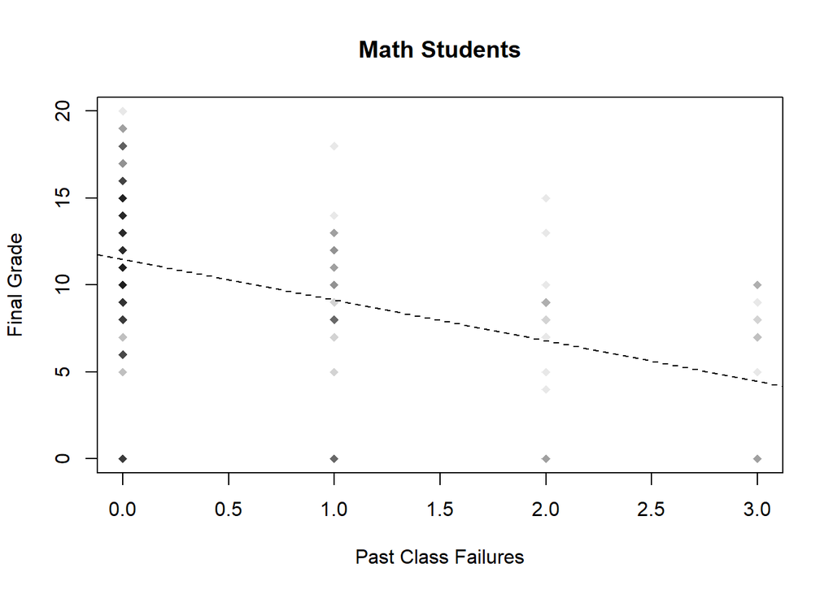

```r
plot(x = school1$failures, y = school1$G3,
     pch = 18,
     col = gray(.1, .1),
     xlab = "Past Class Failures",
     ylab = "Final Grade",
     main = "Math Students"
)
abline(m1failure, lty = 2)
```

Final Grade scores have a negative linear relationship with the amount of past class failures for Math.

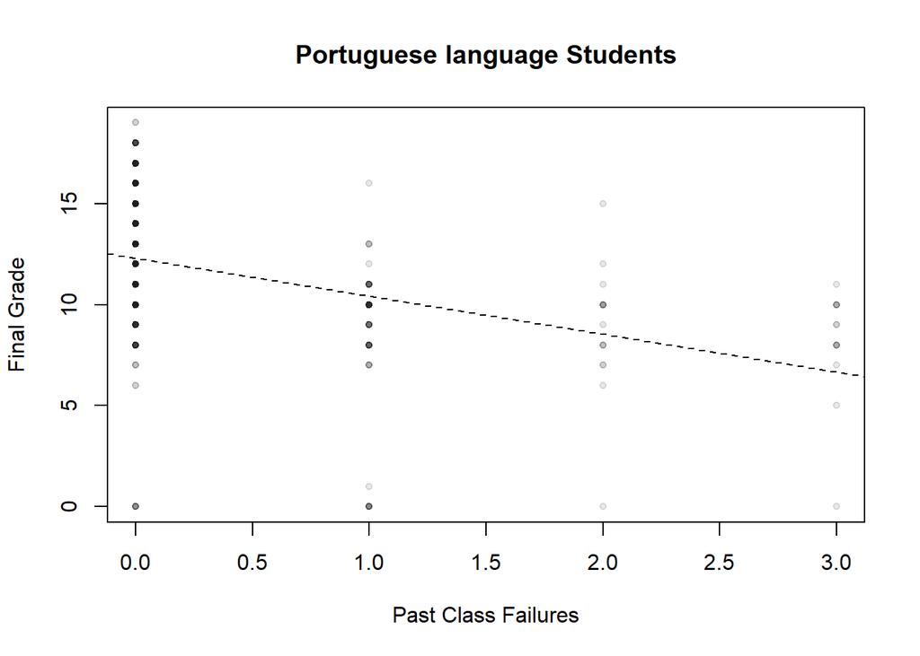

```r
m2failure <- lm(G3 ~failures, data = Ptrain)
plot(x = school2$failures, y = school2$G3,
     pch = 20,
     col = gray(.1, .1),
     xlab = "Past Class Failures",
     ylab = "Final Grade",
     main = "Portuguese language Students"
)
abline(m2failure, lty = 2)
```

Final grade scores have a negative linear relationship with the amount of past class failures for Portuguese language.

There is a negative linear relationship between the number of past class failures and final grades for both Math and Portuguese.

Hence, the more the number of past class failures, the lower the final grade achieved for students in both courses